# almond_SA

AnnaClaire Marley, Ted Jiang

4/27/2020

## Reading in libraries and dataset

## Sensitivity Analysis on Almond Yield Function

- **Perform a sensitivity analysis of how mean anomaly varies all of the parameters used in the almond yield model**
- **Assume parameters are normally distributed with standard deviation of 20% mean value**

#### **Latin Hypercube Method**

```r
# All parameters of almond yield model
factors = c("a", "b", "c", "d", "e")

# Decide How many parameter sets to run
nsets = 1000

# choose distributions for parameters -
q = c("qnorm", "qnorm", "qnorm", "qnorm", "qnorm")
q.arg = list(list(mean = -0.015, sd = 0.015/5),
             list(mean = -0.0046, sd = 0.0046/5),
             list(mean = -0.07, sd = 0.07/5),
             list(mean = 0.0043, sd = 0.0043/5),
             list(mean = 0.28, sd = 0.28/5))

# generate samples from LHS
sens_almond = LHS(NULL, factors, nsets, q, q.arg)

# set of values generaated for each parameter
sens_pars = get.data(sens_almond)
head(sens_pars)
```

```
##              a            b           c           d         e
## 1 -0.017434911 -0.003188609 -0.07768611 0.004525679 0.2964463
## 2 -0.016373801 -0.004879834 -0.05829214 0.005727234 0.3196431
## 3 -0.007963407 -0.004501805 -0.09243786 0.003794919 0.2820358
## 4 -0.010050837 -0.004266527 -0.06231389 0.003559168 0.2614904
## 5 -0.014973680 -0.004658846 -0.09602868 0.003643152 0.2323672
## 6 -0.013422483 -0.006174524 -0.07061432 0.004820532 0.1796015
```

```r
# now run the model for each set of parameter samples
# first create a data structure to store results
sens_results = matrix(nrow=nsets, ncol=1)

# read in the input data
clim <- read.table("clim.txt")

# run the almond yield model for each parameter set
tmp = mapply(FUN=almond_anomaly,
             a = sens_pars$a,
             b = sens_pars$b,
             c = sens_pars$c,
             d = sens_pars$d,
             e = sens_pars$e,
             MoreArgs=list(clim_data = clim,
                           mean_only = TRUE))
#head(tmp)

# turn into matrix using unlist
sens_results_LH = matrix((unlist(tmp)), ncol=1, byrow=TRUE)
colnames(sens_results_LH) = c("mean_yield")
```

**Rank the parameters in term of their sensitivity**

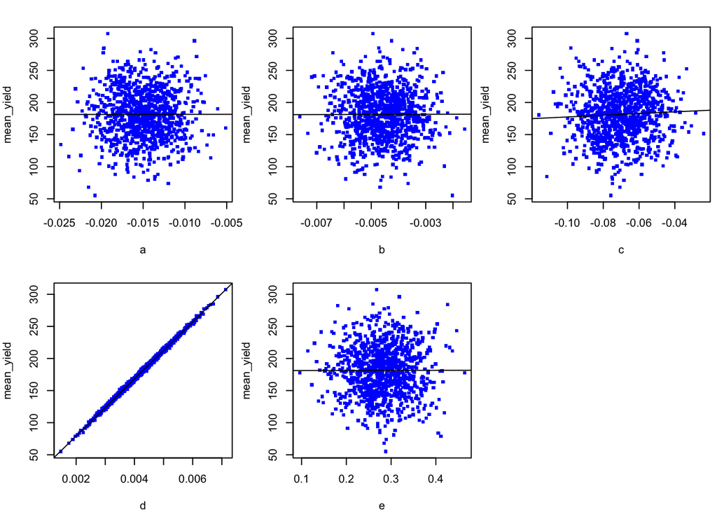

```r
# send results back
# tell() provides the sensitivity structure created by LHS, results from model simulations
sens_almond = pse::tell(sens_almond, t(sens_results_LH),
                        res.names=c("mean_yield"))
# plot sensitivity
pse::plotscatter(sens_almond, col="blue", cex=5)
```

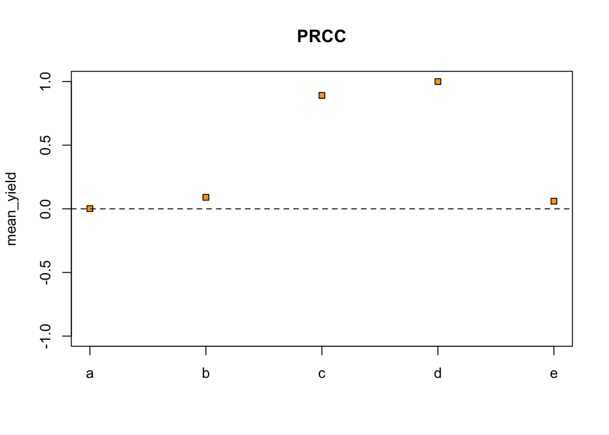

```r
# Plot the partial rank correlation coefficient
pse::plotprcc(sens_almond)
```

```r
sens_almond$prcc
```

```
## [[1]]
##
## Call:
## pcc.default(X = L, y = r, rank = T, nboot = nboot)
##
## Partial Rank Correlation Coefficients (PRCC):
##      original
## a 0.001499661
## b 0.090196822
## c 0.890737669
## d 0.999736721
## e 0.059738258
```

Sensitivity ranking

- 1. d (precip^2 coefficient)
- 2. c (precip coefficient)
- 3. b (temp^2 coefficient)
- 4. e (model intercept)
- 5. a (temp coefficient)

**Graph uncertainty in mean yield anomaly across all parameter uncertainty (boxplot and cummulative distribution of the output).**

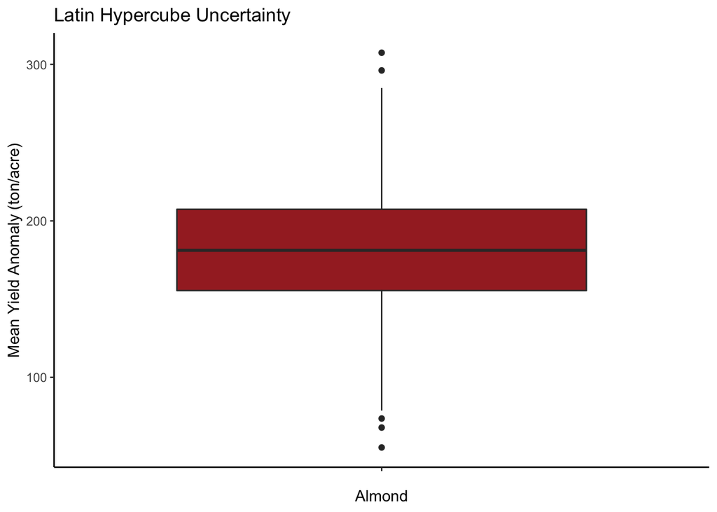

```r
# make it a dataframe
sens_results_LH = as.data.frame(sens_results_LH)

# boxplot
boxplot_LH <-  ggplot(data = sens_results_LH, aes(x = " ", y = mean_yield)) +
                  geom_boxplot(fill = "brown") +
                  labs(
                   title = "Latin Hypercube Uncertainty",
                    x = "Almond",
                    y = "Mean Yield Anomaly (ton/acre)"
                    ) +
                  theme_classic()
  boxplot_LH
```

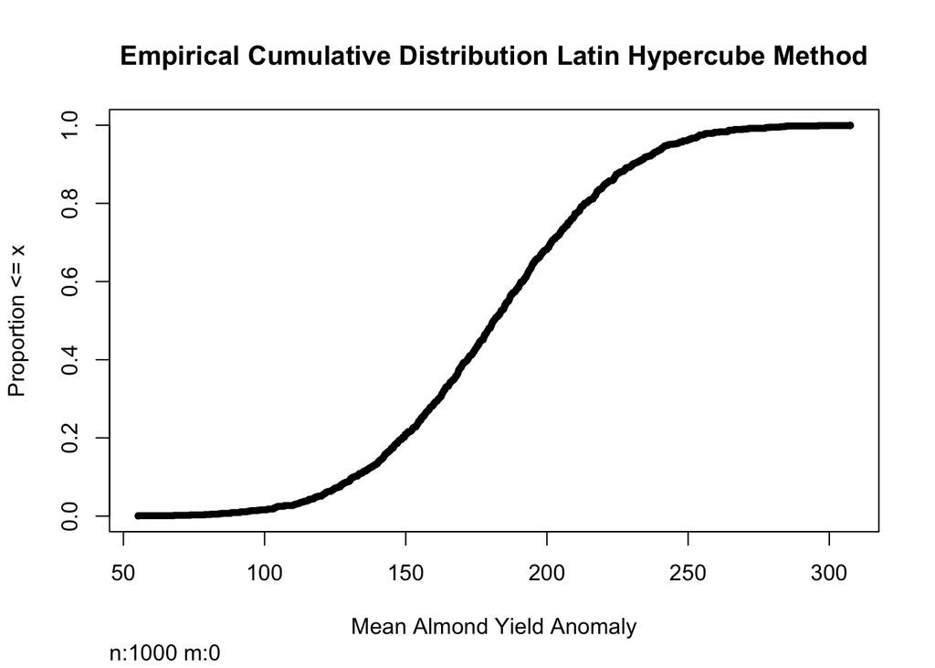

```r
# cumulative distribution
sens_almond_cdf = pse::tell(sens_almond, sens_results_LH, res.names=c("mean_yield"))

plotecdf(sens_almond_cdf, col = "red", lwd = 5,
         xlab = "Mean Almond Yield Anomaly",
         main = "Empirical Cumulative Distribution Latin Hypercube Method")
```

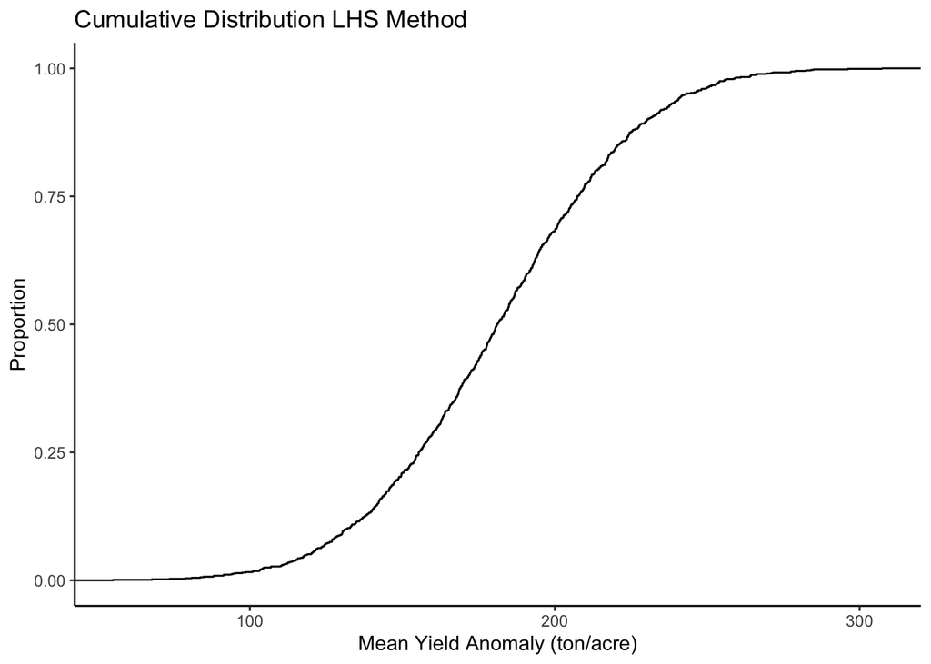

```r
# or using ggplot
cum_dist_lh_gg <- ggplot(sens_results_LH, aes(mean_yield)) +
                  stat_ecdf(geom = "step") +
                  xlab("Mean Yield Anomaly (ton/acre)") +
                  ylab("Proportion") +
                  labs(title = "Cumulative Distribution LHS Method") +
                 theme_classic()
cum_dist_lh_gg
```

#### **Sobel method**

Workflow:

- run sobel to get parameter sets in a sensitivity analysis object
- run model with those parameter sets
- tell the senstivity object about results associated with each parameter set
- look at sensitivity analysis metric from sobel

```r
# number of runs
np=1000

### generate two examples of random number from parmeter distributions ####

  # naming parameters
  a = rnorm(mean = -0.015, sd = 0.015/5, n=np)
  b = rnorm(mean = -0.0046, sd = 0.0046/5, n=np)
  c = rnorm(mean = -0.07, sd = 0.07/5, n=np)
  d = rnorm(mean = 0.0043, sd = 0.0043/5, n=np)
  e = rnorm(mean = 0.28, sd = 0.28/5, n=np)

  # create dataframe
  X1 = cbind.data.frame(a, b, c, d, e)

  ## repeat process for second dataframe
  # naming parameters
  a = rnorm(mean = -0.015, sd = 0.015/5, n=np)
  b = rnorm(mean = -0.0046, sd = 0.0046/5, n=np)
  c = rnorm(mean = -0.07, sd = 0.07/5, n=np)
  d = rnorm(mean = 0.0043, sd = 0.0043/5, n=np)
  e = rnorm(mean = 0.28, sd = 0.28/5, n=np)

  # create dataframe
  X2 = cbind.data.frame(a, b, c, d, e)

# run sobel sensitivity
sens_sobel = sobol2007(model = NULL, X1, X2, nboot = 100)

# run model with parameters generated from sobel
res = mapply(FUN = almond_anomaly,
             a = sens_sobel$X$a,
             b = sens_sobel$X$b,
             c = sens_sobel$X$c,
             d = sens_sobel$X$d,
             e = sens_sobel$X$e,
             MoreArgs=list(clim_data = clim,
                           mean_only = TRUE))


sens_sobel_tell = sensitivity::tell(sens_sobel, res, res.names="mean_yield")

print(sens_sobel_tell)
```

```
##
## Call:
## sobol2007(model = NULL, X1 = X1, X2 = X2, nboot = 100)
##
## Model runs: 7000
##
## First order indices:
##        original          bias   std. error     min. c.i.    max. c.i.
## a  5.171123e-05  1.301148e-05 0.0001773991 -0.0004388738 0.0003585747
## b -3.146301e-04 -3.079909e-05 0.0005271942 -0.0011940701 0.0008017735
## c  6.716546e-03  5.645720e-04 0.0103771702 -0.0162724282 0.0305622583
## d  1.172151e+00  2.771031e-02 0.2094500878  0.6595398358 1.5314277003
## e -2.444939e-04 -3.133833e-05 0.0003335329 -0.0009494883 0.0003903505
##
## Total indices:
##        original          bias   std. error     min. c.i.    max. c.i.
## a  0.0000386103 -6.080813e-06 0.0001727181 -0.0002708428 0.0004827291
## b  0.0003805021 -1.056678e-05 0.0005046512 -0.0007034412 0.0012290080
## c -0.0029345815  9.784213e-06 0.0101742949 -0.0256027389 0.0179530822
## d  0.9300852458 -2.865576e-02 0.1861146681  0.6367120627 1.3831690123
## e  0.0004711157  2.742093e-05 0.0003333340 -0.0001354371 0.0010948374
```

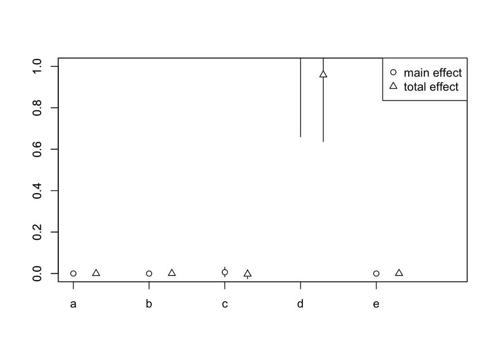

```r
plot(sens_sobel_tell)
```

```r
#For testing purpose
sum(sens_sobel_tell$S$original)
```

```
## [1] 1.17836
```

```r
sum(sens_sobel_tell$T$original)
```

```
## [1] 0.9280409
```

**Rank the parameters in term of their sensitivity**

**Graph uncertainty in mean yield anomaly across all parameter uncertainty (boxplot and cummulative distribution of the output).**

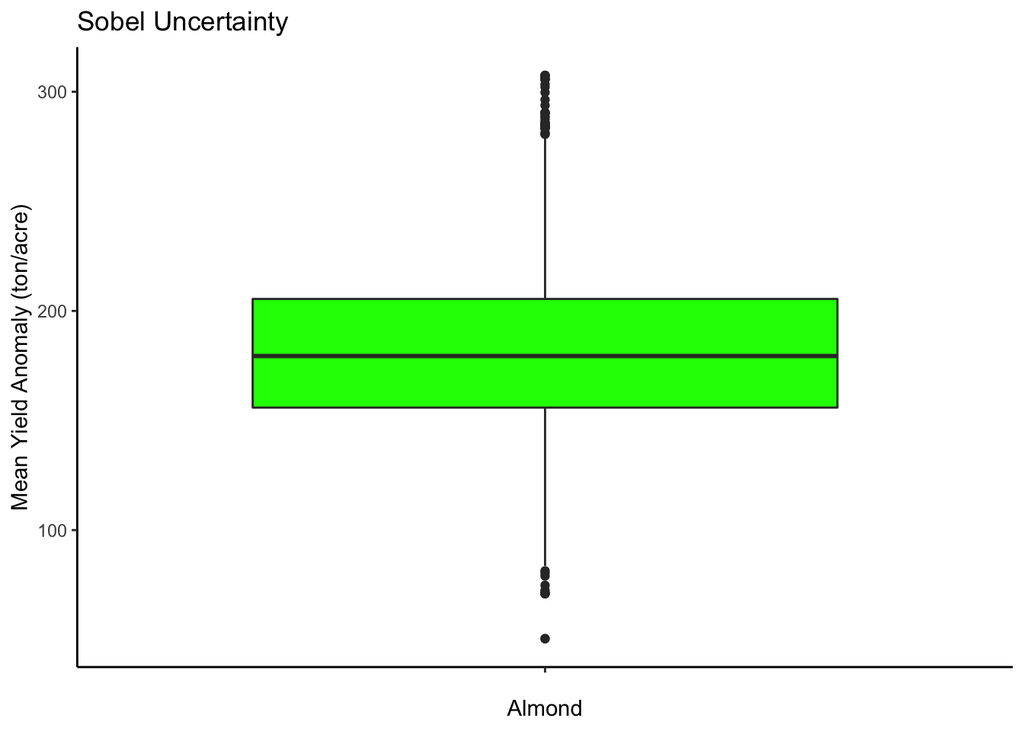

```r
# turn into matrix using unlist
results_sobel = matrix((unlist(res)), ncol=1, byrow=TRUE)
colnames(results_sobel) = c("mean_yield")

# make a data frame for plotting
results_sobel_df <- as.data.frame(results_sobel)

# boxplot
boxplot_sobel <- ggplot(data = results_sobel_df, aes(x = " ", y = mean_yield)) +
          geom_boxplot(fill = "green") +
          labs(
           title = "Sobel Uncertainty",
            x = "Almond",
            y = "Mean Yield Anomaly (ton/acre)"
            ) +
          theme_classic()

boxplot_sobel
```

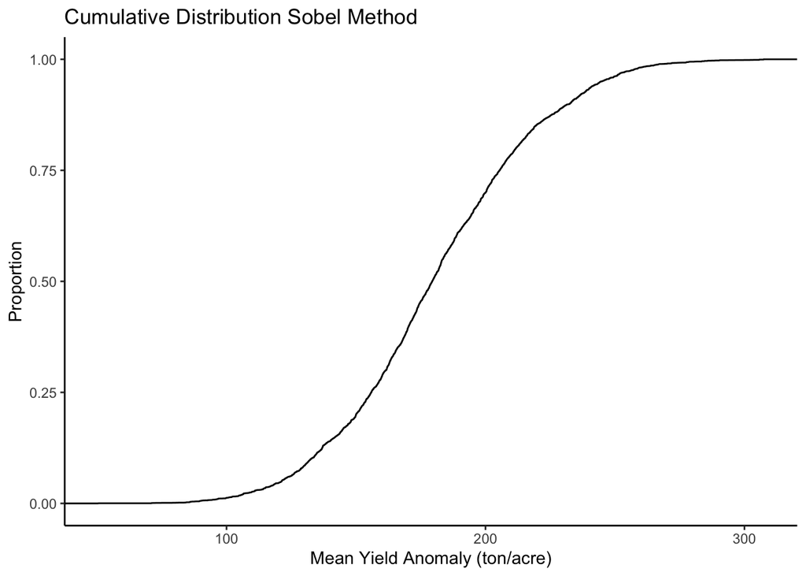

```r
# cumulative distribution
cum_dis_sobel <- ggplot(results_sobel_df, aes(mean_yield)) +
                stat_ecdf(geom = "step") +
                xlab("Mean Yield Anomaly (ton/acre)") +
                ylab("Proportion") +
                labs(title = "Cumulative Distribution Sobel Method") +
                theme_classic()
cum_dis_sobel
```

#### All graphs

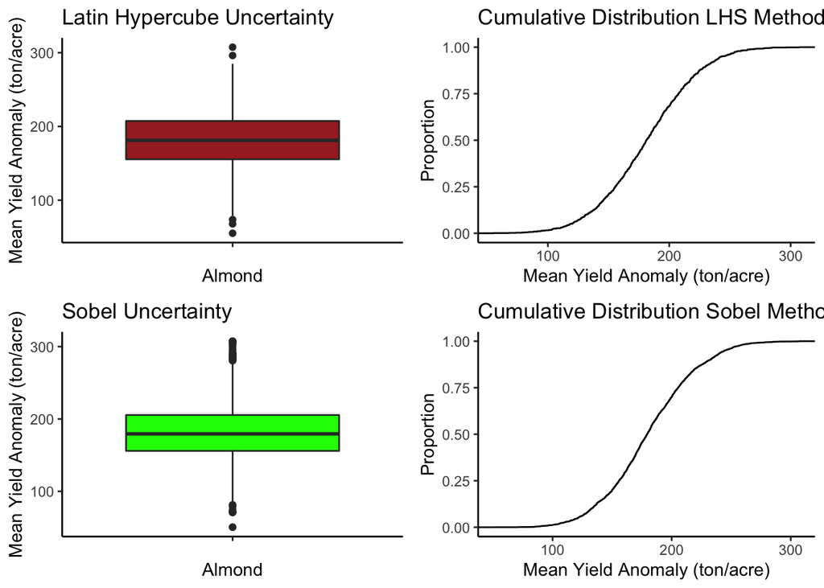

```r
grid.arrange(boxplot_LH, cum_dist_lh_gg, boxplot_sobel, cum_dis_sobel, ncol = 2)
```

## Repeat using twice as many parameter sets

#### **Latin Hypercube Method**

```r
# All parameters of almond yield model
factors = c("a", "b", "c", "d", "e")

# Decide How many parameter sets to run
nsets = 2000

# choose distributions for parameters -
q = c("qnorm", "qnorm", "qnorm", "qnorm", "qnorm")
q.arg = list(list(mean = -0.015, sd = 0.015/5),
             list(mean = -0.0046, sd = 0.0046/5),
             list(mean = -0.07, sd = 0.07/5),
             list(mean = 0.0043, sd = 0.0043/5),
             list(mean = 0.28, sd = 0.28/5))

# generate samples from LHS
sens_almond = LHS(NULL, factors, nsets, q, q.arg)

# set of values generaated for each parameter
sens_pars = get.data(sens_almond)
head(sens_pars)
```

```
##             a            b           c           d         e
## 1 -0.01276613 -0.004824160 -0.05150594 0.003487032 0.3008616
## 2 -0.01869961 -0.004185731 -0.05520164 0.005603826 0.2008423
## 3 -0.02174759 -0.005334748 -0.05171384 0.004923433 0.3216989
## 4 -0.01885751 -0.002500726 -0.07856880 0.003988850 0.2276087
## 5 -0.01518624 -0.004689502 -0.08079889 0.004444571 0.3185238
## 6 -0.01348902 -0.004585586 -0.08704184 0.005866665 0.2676533
```

```r
# now run the model for each set of parameter samples
# first create a data structure to store results
sens_results = matrix(nrow=nsets, ncol=1)

# read in the input data
clim <- read.table("clim.txt")

# run the almond yield model for each parameter set
tmp = mapply(FUN=almond_anomaly,
             a = sens_pars$a,
             b = sens_pars$b,
             c = sens_pars$c,
             d = sens_pars$d,
             e = sens_pars$e,
             MoreArgs=list(clim_data = clim,
                           mean_only = TRUE))
head(tmp)
```

```
## [1] 147.7956 241.2512 211.4622 166.6072 186.4673 248.7950
```

```r
# turn into matrix using unlist
sens_results_LH = matrix((unlist(tmp)), ncol=1, byrow=TRUE)
colnames(sens_results_LH) = c("mean_yield")
```

**Rank the parameters in term of their sensitivity**

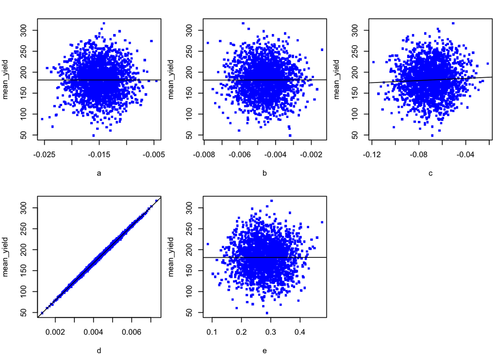

```r
# send results back
# tell() provides the sensitivity structure created by LHS, results from model simulations
sens_almond = pse::tell(sens_almond, t(sens_results_LH),
                        res.names=c("mean_yield"))
# plot sensitivity
pse::plotscatter(sens_almond, col="blue", cex=5)
```

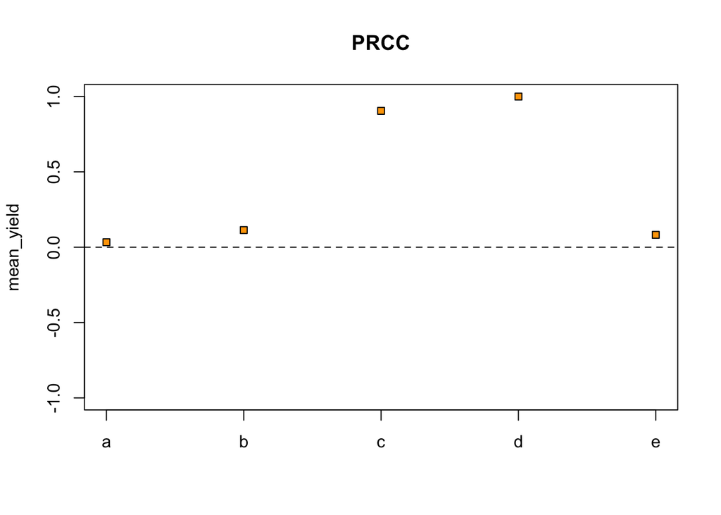

```r
# Plot the partial rank correlation coefficient
pse::plotprcc(sens_almond)
```

```r
sens_almond$prcc
```

```
## [[1]]
##
## Call:
## pcc.default(X = L, y = r, rank = T, nboot = nboot)
##
## Partial Rank Correlation Coefficients (PRCC):
##     original
## a 0.03287422
## b 0.11346698
## c 0.90489014
## d 0.99976075
## e 0.08193201
```

Sensitivity ranking

- 1. d (precip^2 coefficient)
- 2. c (precip coefficient)
- 3. b (temp^2 coefficient)
- 4. e (model intercept)
- 5. a (temp coefficient)

**Graph uncertainty in mean yield anomaly across all parameter uncertainty (boxplot and cummulative distribution of the output).**

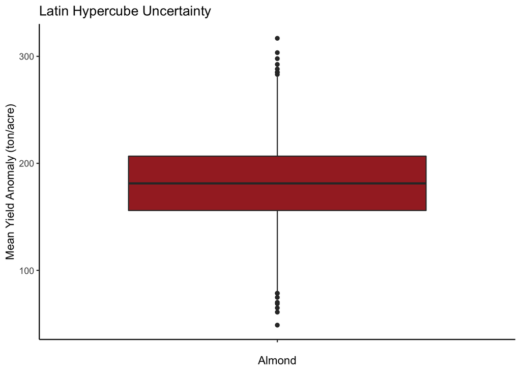

```r
# make it a dataframe
sens_results_LH = as.data.frame(sens_results_LH)

# boxplot
boxplot_LH <-  ggplot(data = sens_results_LH, aes(x = " ", y = mean_yield)) +
                  geom_boxplot(fill = "brown") +
                  labs(
                   title = "Latin Hypercube Uncertainty",
                    x = "Almond",
                    y = "Mean Yield Anomaly (ton/acre)"
                    ) +
                  theme_classic()
  boxplot_LH
```

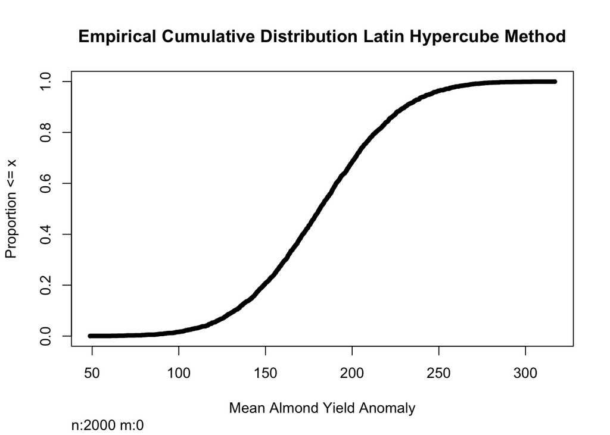

```r
# cumulative distribution
sens_almond_cdf = pse::tell(sens_almond, sens_results_LH, res.names=c("mean_yield"))

plotecdf(sens_almond_cdf, col = "red", lwd = 5,
         xlab = "Mean Almond Yield Anomaly",
         main = "Empirical Cumulative Distribution Latin Hypercube Method")
```

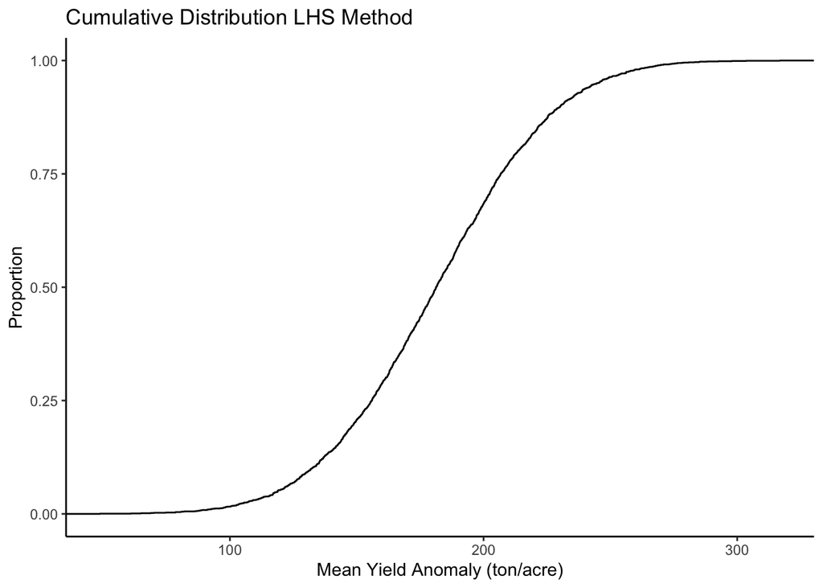

```r
# or using ggplot
cum_dist_lh_gg <- ggplot(sens_results_LH, aes(mean_yield)) +
                  stat_ecdf(geom = "step") +
                  xlab("Mean Yield Anomaly (ton/acre)") +
                  ylab("Proportion") +
                  labs(title = "Cumulative Distribution LHS Method") +
                 theme_classic()
cum_dist_lh_gg
```

#### **Sobel method**

Workflow:

- run sobel to get parameter sets in a sensitivity analysis object
- run model with those parameter sets
- tell the senstivity object about results associated with each parameter set
- look at sensitivity analysis metric from sobel

```r
# number of runs
np=2000

### generate two examples of random number from parmeter distributions ####

  # naming parameters
  a = rnorm(mean = -0.015, sd = 0.015/5, n=np)
  b = rnorm(mean = -0.0046, sd = 0.0046/5, n=np)
  c = rnorm(mean = -0.07, sd = 0.07/5, n=np)
  d = rnorm(mean = 0.0043, sd = 0.0043/5, n=np)
  e = rnorm(mean = 0.28, sd = 0.28/5, n=np)

  # create dataframe
  X1 = cbind.data.frame(a, b, c, d, e)

  ## repeat process for second dataframe
  # naming parameters
  a = rnorm(mean = -0.015, sd = 0.015/5, n=np)
  b = rnorm(mean = -0.0046, sd = 0.0046/5, n=np)
  c = rnorm(mean = -0.07, sd = 0.07/5, n=np)
  d = rnorm(mean = 0.0043, sd = 0.0043/5, n=np)
  e = rnorm(mean = 0.28, sd = 0.28/5, n=np)

  # create dataframe
  X2 = cbind.data.frame(a, b, c, d, e)

# run sobel sensitivity
sens_sobel = sobol2007(model = NULL, X1, X2, nboot = 100)

# run model with parameters generated from sobel
res = mapply(FUN = almond_anomaly,
             a = sens_sobel$X$a,
             b = sens_sobel$X$b,
             c = sens_sobel$X$c,
             d = sens_sobel$X$d,
             e = sens_sobel$X$e,
             MoreArgs=list(clim_data = clim,
                           mean_only = TRUE))


sens_sobel_tell = sensitivity::tell(sens_sobel, res, res.names="mean_yield")

print(sens_sobel_tell)
```

```
##
## Call:
## sobol2007(model = NULL, X1 = X1, X2 = X2, nboot = 100)
##
## Model runs: 14000
##
## First order indices:
##        original          bias   std. error     min. c.i.    max. c.i.
## a  1.420834e-04 -1.066064e-05 0.0001221906 -0.0001251648 0.0003887613
## b  4.586047e-04  4.766428e-05 0.0004125275 -0.0004668722 0.0011810859
## c  3.799493e-03 -2.488452e-04 0.0073293742 -0.0120123086 0.0171972780
## d  9.661841e-01  1.550888e-02 0.1592483208  0.6059727031 1.2404352338
## e -5.687644e-05  2.618953e-06 0.0002212912 -0.0006140550 0.0003076658
##
## Total indices:
##        original          bias   std. error     min. c.i.    max. c.i.
## a -1.473011e-04  1.051773e-05 0.0001257373 -0.0004187626 0.0001052869
## b -5.135764e-04 -3.194514e-05 0.0004213797 -0.0012813442 0.0005288019
## c  3.529062e-03  3.859053e-04 0.0074865347 -0.0107975800 0.0175016455
## d  1.050126e+00 -4.494194e-03 0.1658736846  0.7211483043 1.3976965333
## e -6.419637e-05 -1.547490e-05 0.0002036926 -0.0004135128 0.0004248594
```

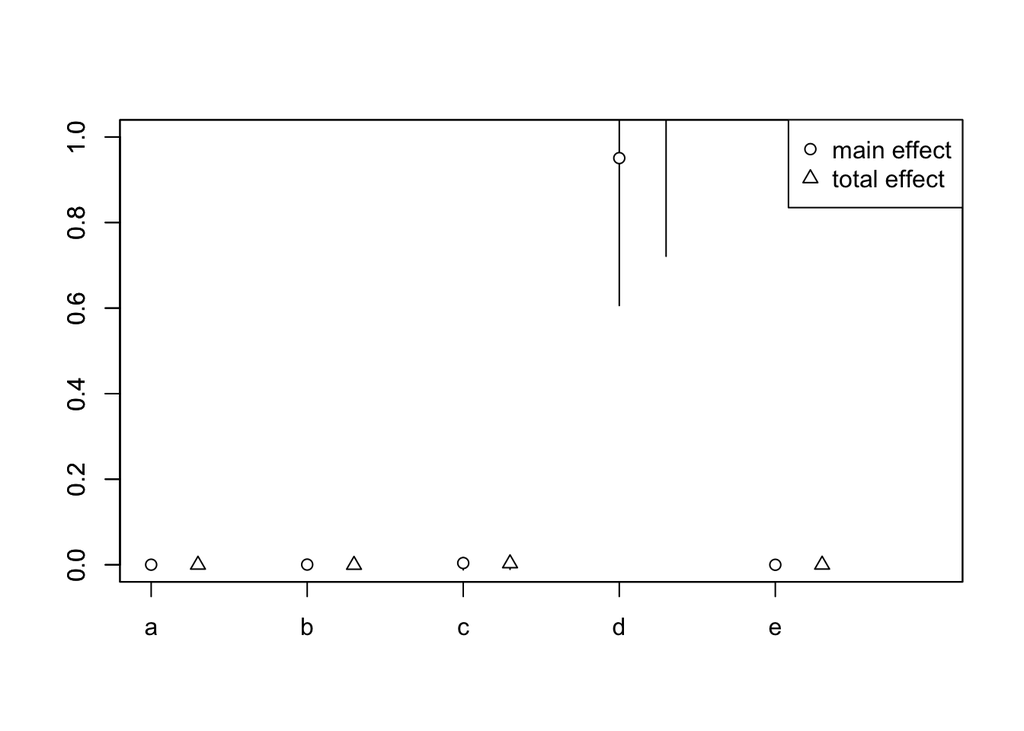

```r
plot(sens_sobel_tell)
```

```r
#For testing purpose
sum(sens_sobel_tell$S$original)
```

```
## [1] 0.9705274
```

```r
sum(sens_sobel_tell$T$original)
```

```
## [1] 1.05293
```

**Rank the parameters in term of their sensitivity**

**Graph uncertainty in mean yield anomaly across all parameter uncertainty (boxplot and cummulative distribution of the output).**

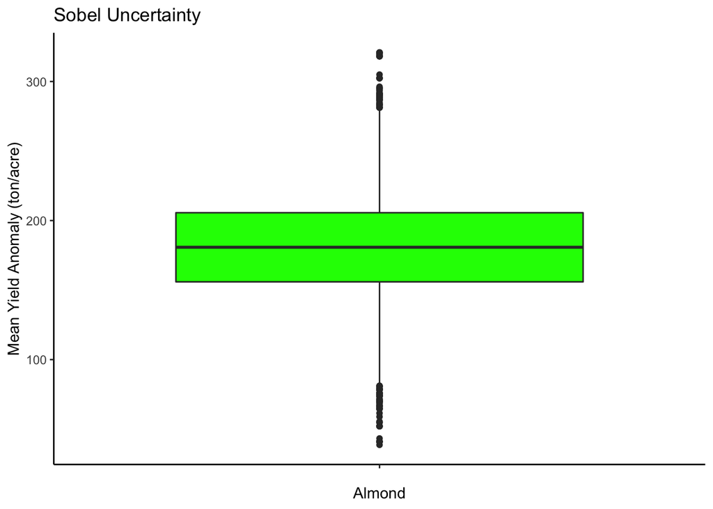

```r
# turn into matrix using unlist
results_sobel = matrix((unlist(res)), ncol=1, byrow=TRUE)
colnames(results_sobel) = c("mean_yield")

# make a data frame for plotting
results_sobel_df <- as.data.frame(results_sobel)

# boxplot
boxplot_sobel <- ggplot(data = results_sobel_df, aes(x = " ", y = mean_yield)) +
          geom_boxplot(fill = "green") +
          labs(
           title = "Sobel Uncertainty",
            x = "Almond",
            y = "Mean Yield Anomaly (ton/acre)"
            ) +
          theme_classic()

boxplot_sobel
```

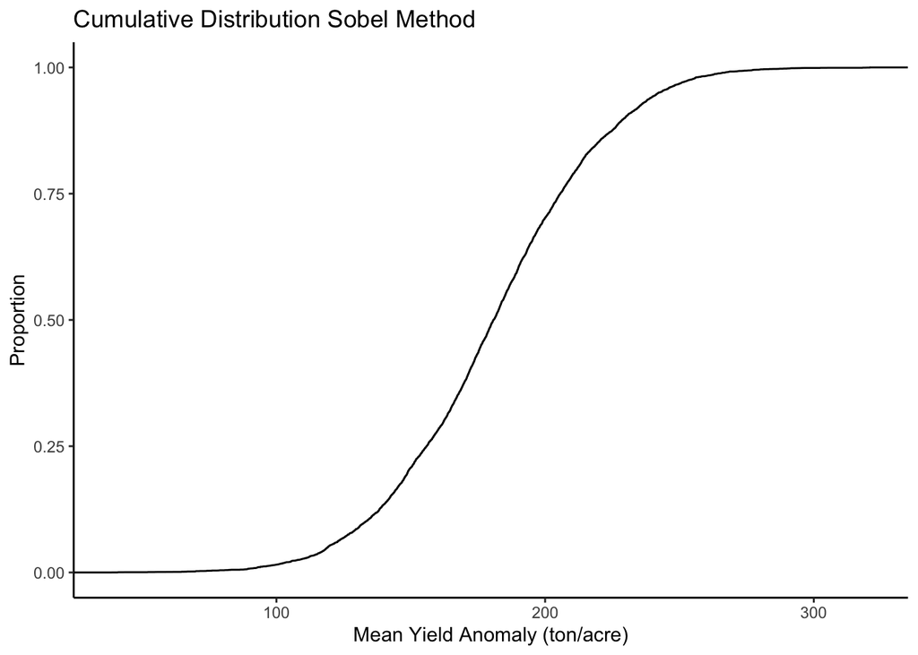

```r
# cumulative distribution
cum_dis_sobel <- ggplot(results_sobel_df, aes(mean_yield)) +
                stat_ecdf(geom = "step") +
                xlab("Mean Yield Anomaly (ton/acre)") +
                ylab("Proportion") +
                labs(title = "Cumulative Distribution Sobel Method") +
                theme_classic()
cum_dis_sobel
```

#### All graphs

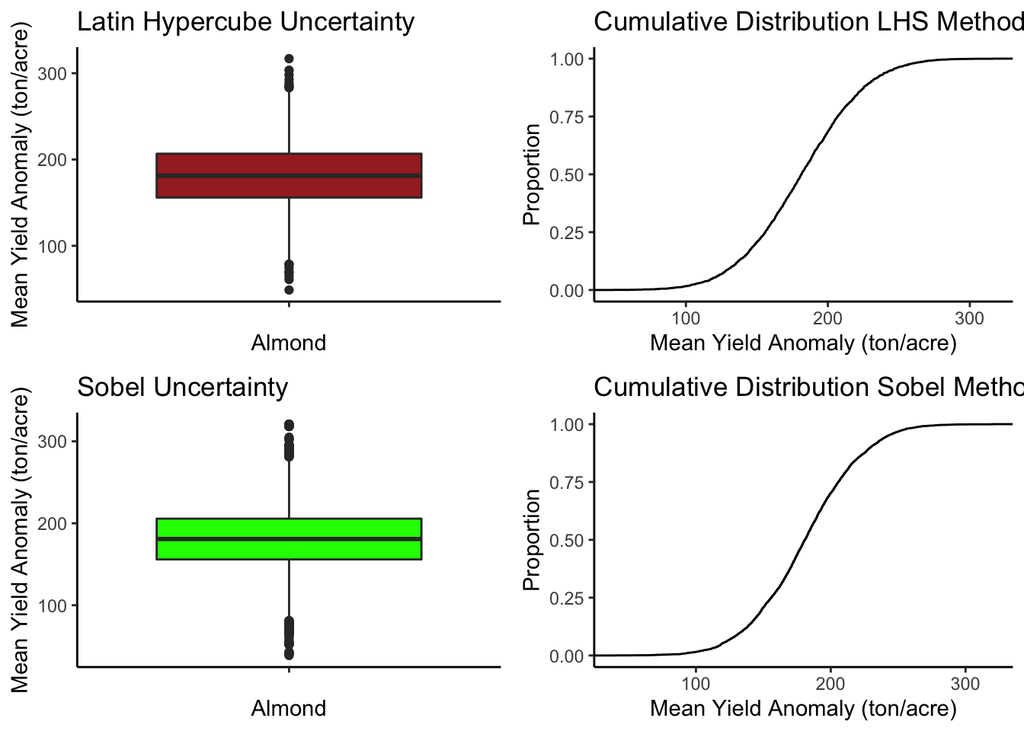

```r
grid.arrange(boxplot_LH, cum_dist_lh_gg, boxplot_sobel, cum_dis_sobel, ncol = 2)
```

#### Try more parameter sets for the Sobel method

```r
# number of runs
np=10000

### generate two examples of random number from parmeter distributions ####

  # naming parameters
  a = rnorm(mean = -0.015, sd = 0.015/5, n=np)
  b = rnorm(mean = -0.0046, sd = 0.0046/5, n=np)
  c = rnorm(mean = -0.07, sd = 0.07/5, n=np)
  d = rnorm(mean = 0.0043, sd = 0.0043/5, n=np)
  e = rnorm(mean = 0.28, sd = 0.28/5, n=np)

  # create dataframe
  X1 = cbind.data.frame(a, b, c, d, e)

  ## repeat process for second dataframe
  # naming parameters
  a = rnorm(mean = -0.015, sd = 0.015/5, n=np)
  b = rnorm(mean = -0.0046, sd = 0.0046/5, n=np)
  c = rnorm(mean = -0.07, sd = 0.07/5, n=np)
  d = rnorm(mean = 0.0043, sd = 0.0043/5, n=np)
  e = rnorm(mean = 0.28, sd = 0.28/5, n=np)

  # create dataframe
  X2 = cbind.data.frame(a, b, c, d, e)

# run sobel sensitivity
sens_sobel = sobol2007(model = NULL, X1, X2, nboot = 100)

# run model with parameters generated from sobel
res = mapply(FUN = almond_anomaly,
             a = sens_sobel$X$a,
             b = sens_sobel$X$b,
             c = sens_sobel$X$c,
             d = sens_sobel$X$d,
             e = sens_sobel$X$e,
             MoreArgs=list(clim_data = clim,
                           mean_only = TRUE))


sens_sobel_tell = sensitivity::tell(sens_sobel, res, res.names="mean_yield")

print(sens_sobel_tell)
```

```
##
## Call:
## sobol2007(model = NULL, X1 = X1, X2 = X2, nboot = 100)
##
## Model runs: 70000
##
## First order indices:
##        original          bias   std. error     min. c.i.    max. c.i.
## a -7.153568e-06 -2.719526e-06 0.0000525099 -1.205833e-04 9.977641e-05
## b  8.301217e-05 -2.577900e-05 0.0001593965 -1.716644e-04 4.815451e-04
## c -1.293653e-03  2.126020e-04 0.0036870036 -8.312216e-03 6.540103e-03
## d  1.011031e+00 -9.048129e-03 0.0739786467  8.826478e-01 1.168566e+00
## e  1.776352e-04 -8.328424e-06 0.0001119988 -1.305176e-06 4.479198e-04
##
## Total indices:
##        original          bias   std. error     min. c.i.     max. c.i.
## a  7.186163e-06  9.274462e-07 5.092236e-05 -9.683465e-05  1.195369e-04
## b -1.743092e-05  2.273245e-05 1.614843e-04 -3.787699e-04  2.747554e-04
## c  4.737425e-03 -2.120656e-04 3.782343e-03 -3.470014e-03  1.192689e-02
## d  9.575430e-01  1.020923e-02 6.914792e-02  8.085684e-01  1.104683e+00
## e -2.098448e-04  1.081320e-05 1.091648e-04 -4.801909e-04 -3.077295e-05
```

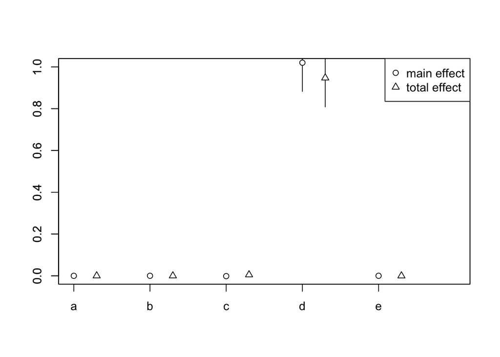

```r
plot(sens_sobel_tell)
```

```r
#For testing purpose
sum(sens_sobel_tell$S$original)
```

```
## [1] 1.009991
```

```r
sum(sens_sobel_tell$T$original)
```

```
## [1] 0.9620603
```

```r
# number of runs
np=20000

### generate two examples of random number from parmeter distributions ####

  # naming parameters
  a = rnorm(mean = -0.015, sd = 0.015/5, n=np)
  b = rnorm(mean = -0.0046, sd = 0.0046/5, n=np)
  c = rnorm(mean = -0.07, sd = 0.07/5, n=np)
  d = rnorm(mean = 0.0043, sd = 0.0043/5, n=np)
  e = rnorm(mean = 0.28, sd = 0.28/5, n=np)

  # create dataframe
  X1 = cbind.data.frame(a, b, c, d, e)

  ## repeat process for second dataframe
  # naming parameters
  a = rnorm(mean = -0.015, sd = 0.015/5, n=np)
  b = rnorm(mean = -0.0046, sd = 0.0046/5, n=np)
  c = rnorm(mean = -0.07, sd = 0.07/5, n=np)
  d = rnorm(mean = 0.0043, sd = 0.0043/5, n=np)
  e = rnorm(mean = 0.28, sd = 0.28/5, n=np)

  # create dataframe
  X2 = cbind.data.frame(a, b, c, d, e)

# run sobel sensitivity
sens_sobel = sobol2007(model = NULL, X1, X2, nboot = 100)

# run model with parameters generated from sobel
res = mapply(FUN = almond_anomaly,
             a = sens_sobel$X$a,
             b = sens_sobel$X$b,
             c = sens_sobel$X$c,
             d = sens_sobel$X$d,
             e = sens_sobel$X$e,
             MoreArgs=list(clim_data = clim,
                           mean_only = TRUE))


sens_sobel_tell = sensitivity::tell(sens_sobel, res, res.names="mean_yield")

print(sens_sobel_tell)
```

```
##
## Call:
## sobol2007(model = NULL, X1 = X1, X2 = X2, nboot = 100)
##
## Model runs: 140000
##
## First order indices:
##        original          bias   std. error     min. c.i.    max. c.i.
## a  1.509611e-05 -3.435385e-06 3.521069e-05 -6.444647e-05 0.0000813489
## b  1.789143e-04  6.290853e-06 1.242211e-04 -5.749128e-05 0.0004437169
## c  1.190141e-03 -7.723774e-06 2.325305e-03 -4.029935e-03 0.0056166544
## d  9.808631e-01  6.319055e-03 4.927278e-02  8.772461e-01 1.0949209777
## e -9.343560e-06 -6.905546e-07 6.326870e-05 -1.438923e-04 0.0001166976
##
## Total indices:
##        original          bias   std. error     min. c.i.    max. c.i.
## a -1.065422e-05  3.447616e-06 3.414650e-05 -7.493671e-05 7.108306e-05
## b -1.265356e-04 -3.750776e-06 1.163329e-04 -3.426042e-04 1.001800e-04
## c  3.617376e-03 -2.967831e-05 2.272451e-03 -1.201387e-03 7.928201e-03
## d  1.019760e+00 -9.544581e-03 4.871078e-02  9.126738e-01 1.122456e+00
## e  1.733814e-05  1.104360e-06 6.474346e-05 -1.067981e-04 1.396141e-04
```

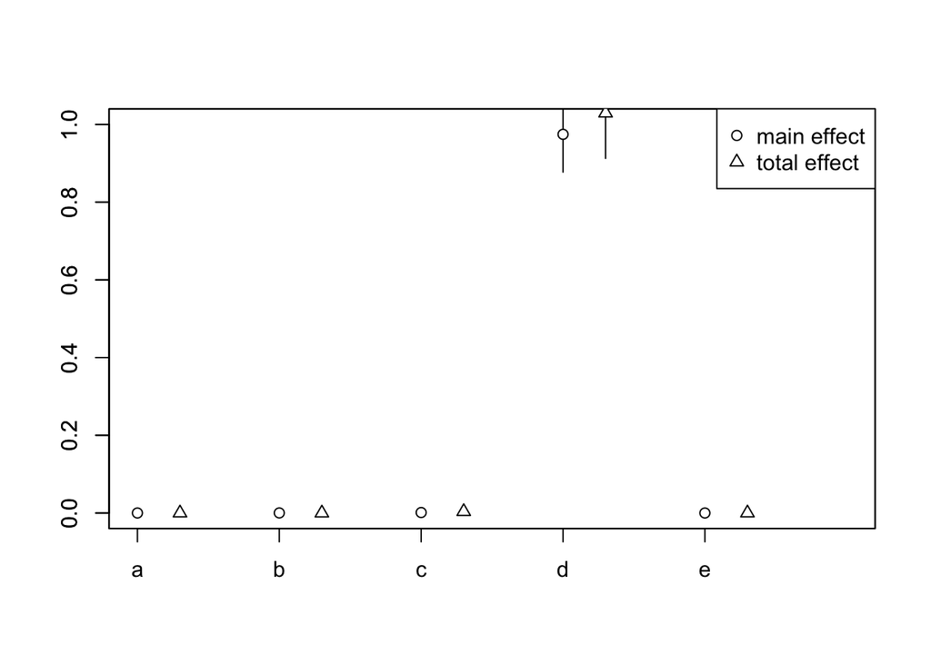

```r
plot(sens_sobel_tell)
```

```r
#For testing purpose
sum(sens_sobel_tell$S$original)
```

```
## [1] 0.9822379
```

```r
sum(sens_sobel_tell$T$original)
```

```
## [1] 1.023258
```

```r
# number of runs
np=50000

### generate two examples of random number from parmeter distributions ####

  # naming parameters
  a = rnorm(mean = -0.015, sd = 0.015/5, n=np)
  b = rnorm(mean = -0.0046, sd = 0.0046/5, n=np)
  c = rnorm(mean = -0.07, sd = 0.07/5, n=np)
  d = rnorm(mean = 0.0043, sd = 0.0043/5, n=np)
  e = rnorm(mean = 0.28, sd = 0.28/5, n=np)

  # create dataframe
  X1 = cbind.data.frame(a, b, c, d, e)

  ## repeat process for second dataframe
  # naming parameters
  a = rnorm(mean = -0.015, sd = 0.015/5, n=np)
  b = rnorm(mean = -0.0046, sd = 0.0046/5, n=np)
  c = rnorm(mean = -0.07, sd = 0.07/5, n=np)
  d = rnorm(mean = 0.0043, sd = 0.0043/5, n=np)
  e = rnorm(mean = 0.28, sd = 0.28/5, n=np)

  # create dataframe
  X2 = cbind.data.frame(a, b, c, d, e)

# run sobel sensitivity
sens_sobel = sobol2007(model = NULL, X1, X2, nboot = 100)

# run model with parameters generated from sobel
res = mapply(FUN = almond_anomaly,
             a = sens_sobel$X$a,
             b = sens_sobel$X$b,
             c = sens_sobel$X$c,
             d = sens_sobel$X$d,
             e = sens_sobel$X$e,
             MoreArgs=list(clim_data = clim,
                           mean_only = TRUE))


sens_sobel_tell = sensitivity::tell(sens_sobel, res, res.names="mean_yield")

print(sens_sobel_tell)
```

```
##
## Call:
## sobol2007(model = NULL, X1 = X1, X2 = X2, nboot = 100)
##
## Model runs: 350000
##
## First order indices:
##        original          bias   std. error     min. c.i.    max. c.i.
## a -3.554804e-05 -3.337440e-07 2.273545e-05 -7.791221e-05 1.114406e-05
## b -4.038610e-05 -8.318778e-07 7.849681e-05 -2.029051e-04 1.273621e-04
## c  3.278883e-03  1.910475e-04 1.602356e-03  4.297288e-05 5.945903e-03
## d  1.037348e+00  4.426088e-03 3.165689e-02  9.714443e-01 1.098382e+00
## e  2.727413e-05  9.569991e-06 4.661655e-05 -8.400657e-05 1.155676e-04
##
## Total indices:
##        original          bias   std. error     min. c.i.    max. c.i.
## a  3.549853e-05  7.258145e-07 2.322303e-05 -1.547031e-05 8.052261e-05
## b  8.227427e-05  1.833423e-06 7.552528e-05 -7.912937e-05 2.320423e-04
## c  1.831203e-03 -1.555907e-04 1.604338e-03 -1.011720e-03 5.317233e-03
## d  9.558892e-01 -3.789935e-03 2.926662e-02  9.035217e-01 1.016944e+00
## e -3.943707e-05 -8.220043e-06 4.590619e-05 -1.295142e-04 5.829911e-05
```

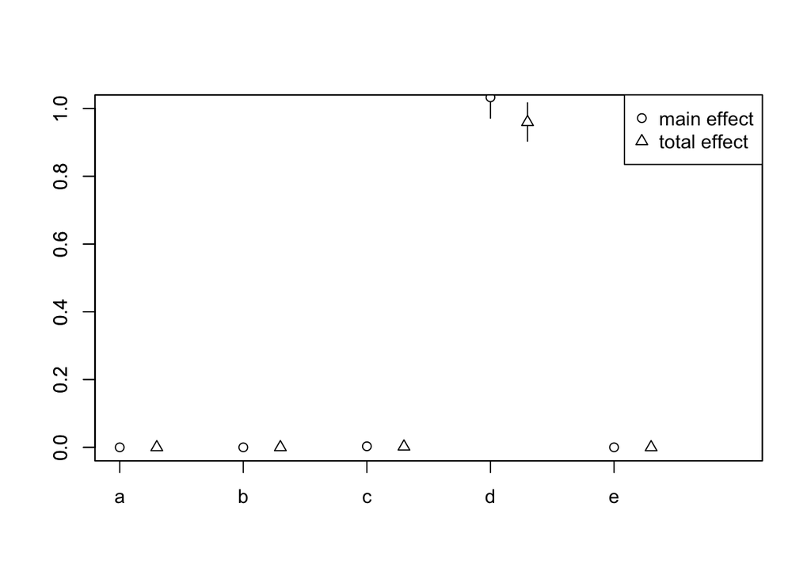

```r
plot(sens_sobel_tell)
```

```r
#For testing purpose
sum(sens_sobel_tell$S$original)
```

```
## [1] 1.040579
```

```r
sum(sens_sobel_tell$T$original)
```

```
## [1] 0.9577987
```

#### Writeup

We did not observe a significant difference in the sensitivity analysis results for either method after changing the simulations runs from 1k to 2k.However, there might be a difference when the number of simulation is even larger.

Additionally for sobol method, we observe that: (1), the error bars for parameter d in the sensitivity index plot are large in both 1k iteration and 2k iteration scenario; (2), everytime we rerun the model, the output sensitivity indexes are significantly different. This probably means that 2k iteration is not large enough for the sensitivity indexes to converge. Hence, we further tried 10k, 20k, and 50k iterations. The results show that (1), with more iterations, the error bars are smaller; (2) With more iterations, the summation of both first-order sensitivity indexes and total sensitivity indexes converge to 1. This probably means that there is no interaction between the five parameters in this model.